# Results for performance benchmarking llama3-8b-instruct

| **Last modified (UTC)** | **FMBench version** |
| --- | --- |
| 2024-09-24 16:10:08.917710 | 2.0.6 |

## Summary

We did performance benchmarking for `llama3-8b-instruct` on “`g5.2xlarge`” on multiple datasets and based on the test results the best price performance for dataset `en_1-500` is provided by the `g5.2xlarge`.

| Information | Value |
| --- | --- |
| experiment_name | llama3-8b-instruct |
| payload_file | payload_en_1-500.jsonl |
| instance_type | g5.2xlarge |
| instance_count | 1.0 |
| concurrency | 1 |
| error_rate | 0.0 |
| prompt_token_count_mean | 284 |
| prompt_token_throughput | 4314 |
| completion_token_count_mean | 61 |
| completion_token_throughput | 76 |
| transactions_per_minute | 911 |
| price_per_txn | 2.2e-05 |
| price_per_token | 0.00000006 |
| latency p50, p95, p99 | 2.96, 2.96, 2.96 |

The price performance comparison for different instance types is presented below. An interactive version of this chart is available here.

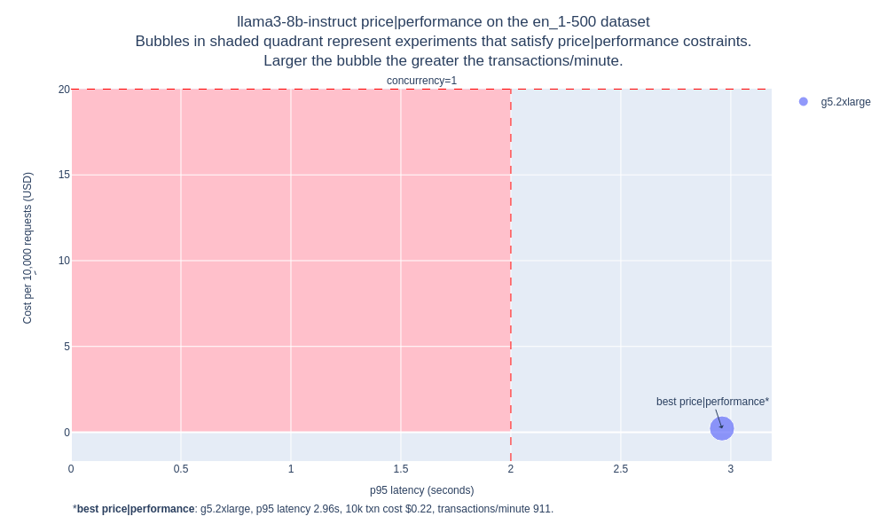

Price performance comparison

### Latency Metrics Analysis

The following table provides token latency metrics including the overall latency, Time To First Token (TTFT), and Time Per Output Token (TPOT) for the `en_1-500` dataset.

*No token latency metrics data is available. To get token latency metrics enable streaming responses by setting `stream: True` in experiment configuration*.

### Failed experiments

There were a total of 1 experiment run(s) that failed at least one configured performance criteria: `Latency` < `2s`, `cost per 10k transactions`: `$20`, `error rate`: `0`. See table below.

| experiment_name | payload_file | concurrency | error_rate_text | latency_p95_text | price_per_10k_txn_text |
| --- | --- | --- | --- | --- | --- |
| llama3-8b-instruct | payload_en_1-500.jsonl | 1 | 0.00 | **2.96** | 0.22 |

### Model evaluations

*Model evaluation data is not available*.

### Endpoint metrics

The following table provides endpoint utilization and invocation metrics.

*No endpoint metrics data is available*.

### Configuration

The configuration used for these tests is available in the `config` file.

### Experiment cost

#### Model Benchmarking Cost

The cost to run each experiment is provided in the table below. The total cost for running all experiments is $0.01.

| experiment_name | instance_type | instance_count | duration_in_seconds | cost |
| --- | --- | --- | --- | --- |
| llama3-8b-instruct | g5.2xlarge | nan | 23.81 | 0.008017 |

#### Model Evaluation Cost

The cost to evaluate 1 candidate models using No LLM evaluators is 0.

The total cost incurred for **model benchmarking and evaluations**: $0.01.

## Per instance results

The following table provides the best combinations for running inference for different sizes prompts on different instance types. The following dataset(s) were used for this test: `2wikimqa_e.jsonl`, `2wikimqa.jsonl`, `hotpotqa_e.jsonl`, `hotpotqa.jsonl`, `narrativeqa.jsonl`, `triviaqa_e.jsonl`, `triviaqa.jsonl`.

[output not shown]

## Plots

The following plots provide insights into the results from the different experiments run.

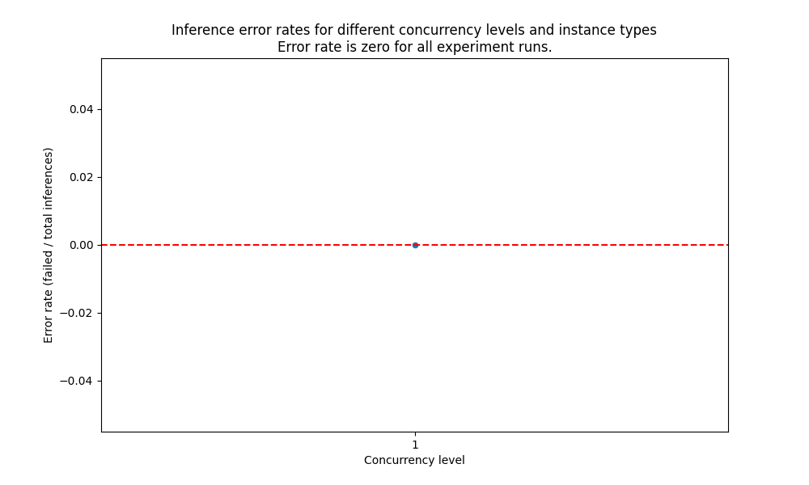

Error rates for different concurrency levels and instance types

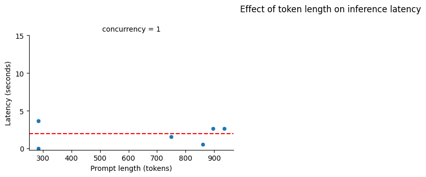

Tokens vs latency for different concurrency levels and instance types

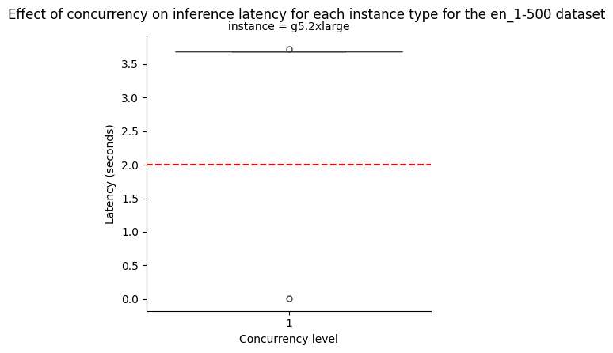

Concurrency Vs latency for different instance type for selected dataset

## Configuration file

```bash
aws:
  bucket: placeholder
  local_file_system_path: /tmp/fmbench-write
  region: us-east-1
  s3_and_or_local_file_system: local
  sagemaker_execution_role: arn:aws:iam::471112568442:role/EC2
datasets:
  filters:
  - language: en
    max_length_in_tokens: 500
    min_length_in_tokens: 1
    payload_file: payload_en_1-500.jsonl
  - language: en
    max_length_in_tokens: 1000
    min_length_in_tokens: 500
    payload_file: payload_en_500-1000.jsonl
  prompt_template_keys:
  - input
  - context
dir_paths:
  all_prompts_file: all_prompts.csv
  data_prefix: data
  metadata_dir: metadata
  metrics_dir: metrics
  models_dir: models
  prompts_prefix: prompts
experiments:
- bucket: placeholder
  concurrency_levels:
  - 1
  deploy: true
  deployment_script: ec2_deploy.py
  ec2:
    gpu_or_neuron_setting: --gpus all --shm-size 12g
    model_loading_timeout: 2400
  env: null
  ep_name: http://127.0.0.1:8080/invocations
  image_uri: 763104351884.dkr.ecr.us-east-1.amazonaws.com/djl-inference:0.29.0-lmi11.0.0-cu124
  inference_script: ec2_predictor.py
  inference_spec:
    model_loading_timeout: 2400
    parameter_set: ec2_djl
    parameters:
      Content-type: application/json
      do_sample: true
      max_new_tokens: 100
      return_full_text: false
      temperature: 0.1
      top_k: 120
      top_p: 0.92
    shm_size: 12g
    tp_degree: 1
  instance_count: null
  instance_type: g5.2xlarge
  model_id: meta-llama/Meta-Llama-3-8B-Instruct
  model_name: llama3-8b-instruct
  model_version: null
  name: llama3-8b-instruct
  payload_files:
  - payload_en_1-500.jsonl
  - payload_en_500-1000.jsonl
  region: us-east-1
  serving.properties: 'engine=MPI

    option.tensor_parallel_degree=1

    option.max_rolling_batch_size=256

    option.model_id=meta-llama/Meta-Llama-3-8B-Instruct

    option.rolling_batch=lmi-dist

    '
general:
  model_name: llama3-8b-instruct
  name: llama3-8b-g5.2xl-ec2
inference_parameters:
  ec2_djl:
    Content-type: application/json
    do_sample: true
    max_new_tokens: 100
    return_full_text: false
    temperature: 0.1
    top_k: 120
    top_p: 0.92
metrics:
  dataset_of_interest: en_1-500
pricing: pricing.yml
report:
  all_metrics_file: all_metrics.csv
  cost_per_10k_txn_budget: 20
  error_rate_budget: 0
  latency_budget: 2
  per_inference_request_file: per_inference_request_results.csv
  txn_count_for_showing_cost: 10000
  v_shift_w_gt_one_instance: 0.025
  v_shift_w_single_instance: 0.025
run_steps:
  0_setup.ipynb: true
  1_generate_data.ipynb: true
  2_deploy_model.ipynb: true
  3_run_inference.ipynb: true
  4_model_metric_analysis.ipynb: true
  5_cleanup.ipynb: true
s3_read_data:
  config_files:
  - pricing.yml
  configs_prefix: configs
  local_file_system_path: /tmp/fmbench-read
  prompt_template_dir: prompt_template
  prompt_template_file: prompt_template_llama3.txt
  read_bucket: sagemaker-fmbench-read-us-east-1-471112568442
  s3_or_local_file_system: local
  script_files:
  - hf_token.txt
  scripts_prefix: scripts
  source_data_files:
  - 2wikimqa_e.jsonl
  - 2wikimqa.jsonl
  - hotpotqa_e.jsonl
  - hotpotqa.jsonl
  - narrativeqa.jsonl
  - triviaqa_e.jsonl
  - triviaqa.jsonl
  source_data_prefix: source_data
  tokenizer_prefix: llama3_tokenizer
```